# Investigating_MA_models

Sean Ammirati

July 29, 2018

# Creating a MA simulation

```r
ma1<-arima.sim(list(ma=c(0.7,-0.4)),n=36)
theoreticalac<-ARMAacf(ma=c(.7,-.4))
theoreticalac
```

```
##          0          1          2          3
##  1.0000000  0.2545455 -0.2424242  0.0000000
```

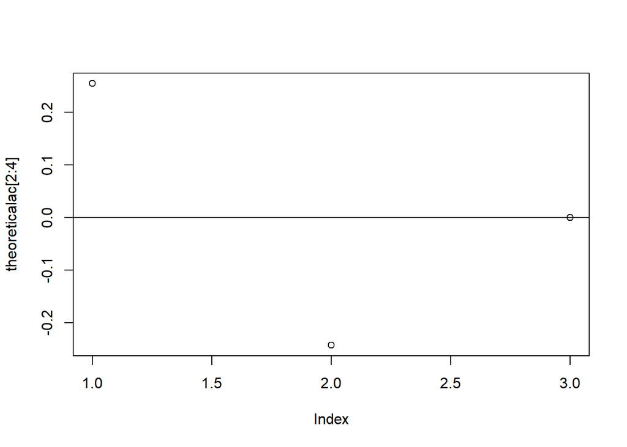

```r
plot(theoreticalac[2:4],type="p")
abline(h=0)
```

I created a simulation of an MA2 model with parameters .7 and -.4 and stored it in an object ma1. I then found the theoretical autocorrelation of a MA2 model with these coefficients. As expected, the theoretical autocorrelations become zero after the second correlation, which is what we would expect. I created a plot to see this.

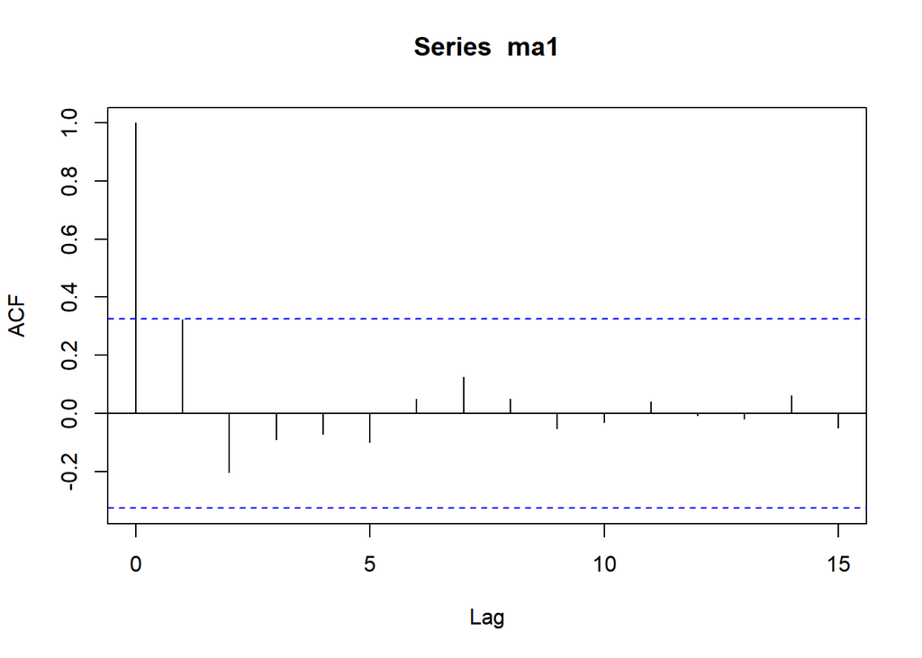

```r
empiricalac<-acf(ma1)
```

```r
empiricalac
```

```
##
## Autocorrelations of series 'ma1', by lag
##
##      0      1      2      3      4      5      6      7      8      9
##  1.000  0.324 -0.203 -0.090 -0.071 -0.098  0.049  0.125  0.050 -0.051
##     10     11     12     13     14     15
## -0.030  0.040 -0.008 -0.019  0.061 -0.051
```

```r
theoreticalpac<-ARMAacf(ma=c(.7,-.4),lag.max=15,pacf=TRUE)
theoreticalpac
```

```
##  [1]  0.25454545 -0.32850242  0.19849096 -0.18271934  0.14522118
##  [6] -0.12756914  0.11004843 -0.09752284  0.08671078 -0.07788419
## [11]  0.07030685 -0.06381051  0.05814052 -0.05315803  0.04873876
```

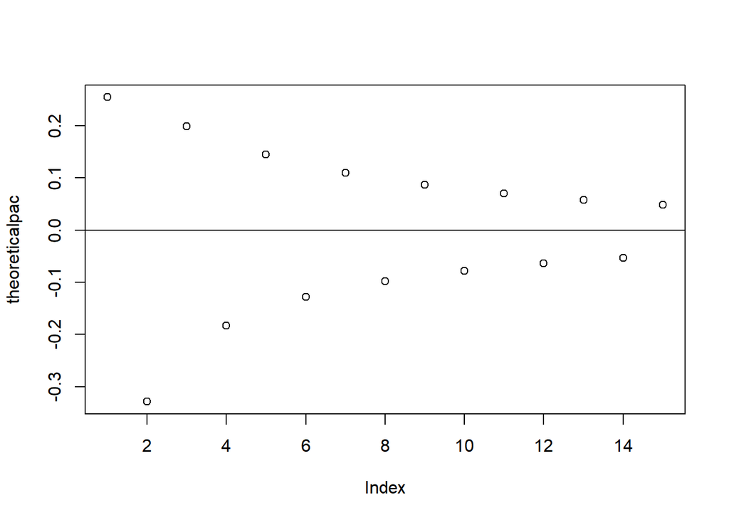

```r
plot(theoreticalpac)
abline(h=0)
```

This is what we would expect - the theoretical partial autocorrelations for the MA model do not cut off as they did in the autocorrelations. They tend towards zero but never actually meet zero.

When we perform the partial autocorrelation function on the simulated model, we see that it actually goes outside of the boundary for lag = 2. Since the partial autocorrelation function of the MA models do not go to exactly zero, we see some more variation in the right hand side of this plot then we did the previous one. This indicates that it is indeed an MA model, as the partial autocorrelations do not have a pattern we’d expect for a AR model. Again, we can see that the simulated partial autocorrelations are similar to those of the theoretical ones.

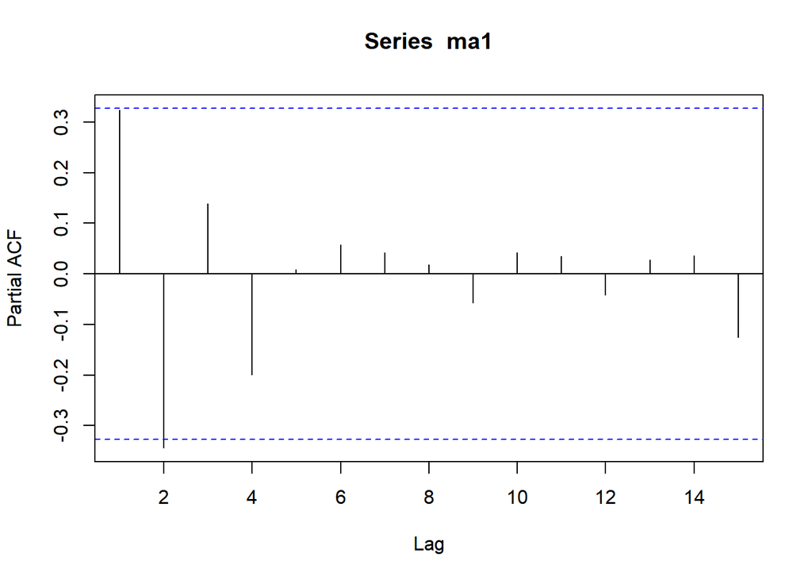

```r
empiricalpac<-pacf(ma1)
```

```r
empiricalpac
```

```
##
## Partial autocorrelations of series 'ma1', by lag
##
##      1      2      3      4      5      6      7      8      9     10
##  0.324 -0.344  0.139 -0.200  0.009  0.057  0.041  0.018 -0.057  0.041
##     11     12     13     14     15
##  0.035 -0.042  0.028  0.036 -0.125
```